## Cantinho do R

### Uma super explosão de cores com o R :D

Ou, se quiser um título chato claro e direto:

### Uma lista prática de cores para o R

*Marcos V. C. Vital*

Para mais material, acesse http://cantinhodor.wordpress.com/

Este documento faz parte do material que disponibilizo no meu blog, o “Cantinho do R”, e foi foi criado utilizando o software R, o programa RStudio e a linguagem Markdown. Para saber mais sobre eles, acesse:

http://www.r-project.org/

http://www.rstudio.com

http://rmarkdown.rstudio.com/

Se Você está olhando este documento e não consegue entender nada, é sinal de que tem que começar do básico com o R. Uma boa pedida é dar uma olhada na minha apostila, para só depois voltar aqui. Confira ela aqui: https://cantinhodor.wordpress.com/2015/03/28/a-boa-e-velha-apostila-basica-do-r/

Oi, pessoal!

Recebi, por email, uma dica bem legal que me foi enviada pelo [Lucas Perillo](http://lattes.cnpq.br/9100354010857966), da [Bocaina Biologia da Conservação](http://www.biologiadaconservacao.com.br/). Ele me enviou uma página da UFPA que mostra uma lista de nomes de cores usadas em linguagens de programação, e que funciona no nosso querido R! O bacana da lista é que ela tem uma tabelinha com os nomes (que o R reconhece) dentro de uma célula da cor correspondendente! Ou seja: você pode acessar a tabela, escolher uma cor que gostar e usar no R!

Então vamos lá? Vou aqui mostrar rapidinho, e depois vocês podem se divertir sozinhos em casa. ;)

#### Cores no R: uma lista imensa.

[A lista está aqui, é só clicar e ser feliz.](http://www.ufpa.br/dicas/htm/htm-cor2.htm)

No R, você pode definir qualquer cor usando o nome entre aspas, é bem fácil. Só para dar um exemplo, veja o gráfico abaixo, no qual usei alguams cores escolhidas arbitrariamente pela lista:

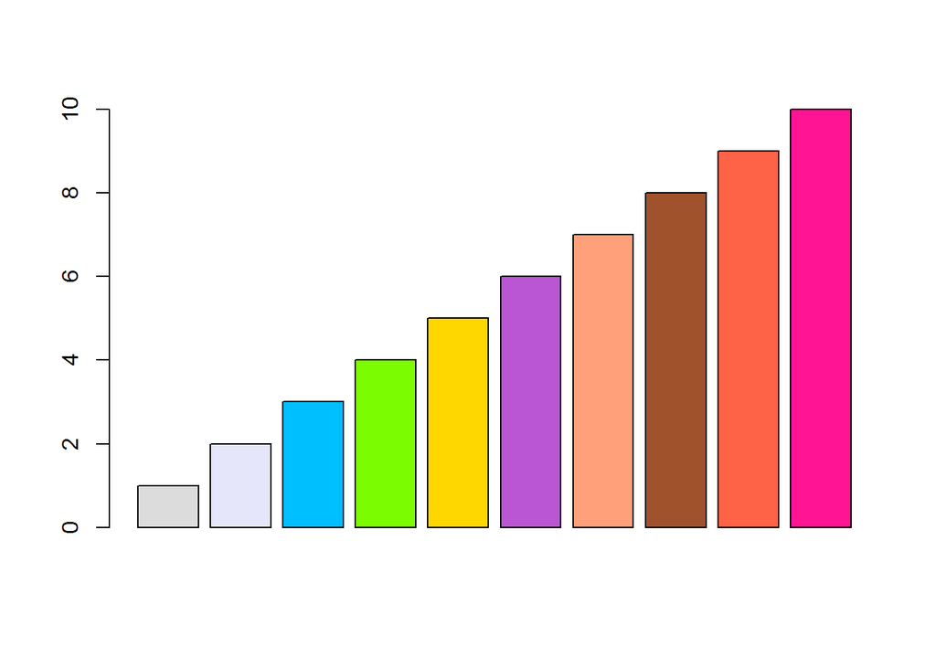

```r
cores<-c("Gainsboro", "Lavender", "DeepSkyBlue", "LawnGreen", "Gold",
         "MediumOrchid","LightSalmon", "Sienna", "Tomato", "DeepPink1" )

barplot(1:10, col=cores)
```

É isso aí. Agora você pode usar aquele tom super específico de violeta claro que sempre teve vontade de colocar no gráfico mas não sabia como. :)

*Bom, pessoal, é isso aí, era curtinho mesmo, só queria mostrar a lista de cores e seu funcionamento no R. Espero que seja útil, ou pelo menos torne seus gráficos mais divertidos e coloridos!*

*Abraços, e até o próximo script!*

*Prof Marcos*